# Risk Factor Analysis

## Outcome Variable

**Outcome Variable:** sstunted

## Predictor Variables

**Intervention Variable:** hdlvry

**Adjustment Set:**

unadjusted

## Stratifying Variables

The analysis was stratified on these variable(s):

- agecat
- studyid
- country

## Data Summary

| agecat | studyid | country | A | n | nA | nAY0 | nAY1 |
| --- | --- | --- | --- | --- | --- | --- | --- |
| Birth | ki1000108-CMC-V-BCS-2002 | INDIA | 0 | 90 | 90 | 87 | 3 |
| Birth | ki1000108-CMC-V-BCS-2002 | INDIA | 1 | 90 | 0 | 0 | 0 |
| Birth | ki1000108-IRC | INDIA | 0 | 388 | 381 | 365 | 16 |
| Birth | ki1000108-IRC | INDIA | 1 | 388 | 7 | 7 | 0 |
| Birth | ki1000109-EE | PAKISTAN | 0 | 2 | 2 | 2 | 0 |
| Birth | ki1000109-EE | PAKISTAN | 1 | 2 | 0 | 0 | 0 |
| Birth | ki1000304b-SAS-CompFeed | INDIA | 0 | 67 | 8 | 7 | 1 |
| Birth | ki1000304b-SAS-CompFeed | INDIA | 1 | 67 | 59 | 56 | 3 |
| Birth | ki1017093c-NIH-Crypto | BANGLADESH | 0 | 27 | 22 | 21 | 1 |
| Birth | ki1017093c-NIH-Crypto | BANGLADESH | 1 | 27 | 5 | 5 | 0 |
| Birth | ki1135781-COHORTS | INDIA | 0 | 4694 | 2938 | 2855 | 83 |
| Birth | ki1135781-COHORTS | INDIA | 1 | 4694 | 1756 | 1702 | 54 |
| Birth | kiGH5241-JiVitA-3 | BANGLADESH | 0 | 142 | 4 | 4 | 0 |
| Birth | kiGH5241-JiVitA-3 | BANGLADESH | 1 | 142 | 138 | 131 | 7 |
| Birth | kiGH5241-JiVitA-4 | BANGLADESH | 0 | 223 | 10 | 9 | 1 |
| Birth | kiGH5241-JiVitA-4 | BANGLADESH | 1 | 223 | 213 | 196 | 17 |
| 3 months | ki1000108-CMC-V-BCS-2002 | INDIA | 0 | 359 | 352 | 319 | 33 |
| 3 months | ki1000108-CMC-V-BCS-2002 | INDIA | 1 | 359 | 7 | 7 | 0 |
| 3 months | ki1000108-IRC | INDIA | 0 | 407 | 399 | 363 | 36 |
| 3 months | ki1000108-IRC | INDIA | 1 | 407 | 8 | 8 | 0 |
| 3 months | ki1000109-EE | PAKISTAN | 0 | 374 | 252 | 166 | 86 |
| 3 months | ki1000109-EE | PAKISTAN | 1 | 374 | 122 | 86 | 36 |
| 3 months | ki1000304b-SAS-CompFeed | INDIA | 0 | 359 | 71 | 66 | 5 |
| 3 months | ki1000304b-SAS-CompFeed | INDIA | 1 | 359 | 288 | 265 | 23 |
| 3 months | ki1000304b-SAS-FoodSuppl | INDIA | 0 | 97 | 24 | 21 | 3 |
| 3 months | ki1000304b-SAS-FoodSuppl | INDIA | 1 | 97 | 73 | 63 | 10 |
| 3 months | ki1017093b-PROVIDE | BANGLADESH | 0 | 645 | 482 | 477 | 5 |
| 3 months | ki1017093b-PROVIDE | BANGLADESH | 1 | 645 | 163 | 158 | 5 |
| 3 months | ki1017093c-NIH-Crypto | BANGLADESH | 0 | 728 | 565 | 542 | 23 |
| 3 months | ki1017093c-NIH-Crypto | BANGLADESH | 1 | 728 | 163 | 153 | 10 |

[output cut: 118 more lines]

The following strata were considered:

- agecat: 12 months, studyid: ki1000108-CMC-V-BCS-2002, country: INDIA
- agecat: 12 months, studyid: ki1000108-IRC, country: INDIA
- agecat: 12 months, studyid: ki1000109-EE, country: PAKISTAN
- agecat: 12 months, studyid: ki1000304b-SAS-CompFeed, country: INDIA
- agecat: 12 months, studyid: ki1000304b-SAS-FoodSuppl, country: INDIA
- agecat: 12 months, studyid: ki1017093b-PROVIDE, country: BANGLADESH
- agecat: 12 months, studyid: ki1017093c-NIH-Crypto, country: BANGLADESH
- agecat: 12 months, studyid: ki1066203-TanzaniaChild2, country: TANZANIA, UNITED REPUBLIC OF
- agecat: 12 months, studyid: ki1113344-GMS-Nepal, country: NEPAL
- agecat: 12 months, studyid: ki1135781-COHORTS, country: INDIA
- agecat: 12 months, studyid: kiGH5241-JiVitA-3, country: BANGLADESH
- agecat: 12 months, studyid: kiGH5241-JiVitA-4, country: BANGLADESH
- agecat: 18 months, studyid: ki1000108-CMC-V-BCS-2002, country: INDIA
- agecat: 18 months, studyid: ki1000108-IRC, country: INDIA
- agecat: 18 months, studyid: ki1000109-EE, country: PAKISTAN
- agecat: 18 months, studyid: ki1000304b-SAS-CompFeed, country: INDIA
- agecat: 18 months, studyid: ki1000304b-SAS-FoodSuppl, country: INDIA
- agecat: 18 months, studyid: ki1017093b-PROVIDE, country: BANGLADESH
- agecat: 18 months, studyid: ki1017093c-NIH-Crypto, country: BANGLADESH
- agecat: 18 months, studyid: ki1066203-TanzaniaChild2, country: TANZANIA, UNITED REPUBLIC OF
- agecat: 18 months, studyid: ki1113344-GMS-Nepal, country: NEPAL
- agecat: 18 months, studyid: kiGH5241-JiVitA-4, country: BANGLADESH
- agecat: 24 months, studyid: ki1000108-CMC-V-BCS-2002, country: INDIA
- agecat: 24 months, studyid: ki1000108-IRC, country: INDIA
- agecat: 24 months, studyid: ki1017093b-PROVIDE, country: BANGLADESH
- agecat: 24 months, studyid: ki1017093c-NIH-Crypto, country: BANGLADESH
- agecat: 24 months, studyid: ki1066203-TanzaniaChild2, country: TANZANIA, UNITED REPUBLIC OF
- agecat: 24 months, studyid: ki1113344-GMS-Nepal, country: NEPAL
- agecat: 24 months, studyid: ki1135781-COHORTS, country: INDIA
- agecat: 24 months, studyid: kiGH5241-JiVitA-3, country: BANGLADESH
- agecat: 24 months, studyid: kiGH5241-JiVitA-4, country: BANGLADESH
- agecat: 3 months, studyid: ki1000108-CMC-V-BCS-2002, country: INDIA
- agecat: 3 months, studyid: ki1000108-IRC, country: INDIA
- agecat: 3 months, studyid: ki1000109-EE, country: PAKISTAN
- agecat: 3 months, studyid: ki1000304b-SAS-CompFeed, country: INDIA
- agecat: 3 months, studyid: ki1000304b-SAS-FoodSuppl, country: INDIA
- agecat: 3 months, studyid: ki1017093b-PROVIDE, country: BANGLADESH
- agecat: 3 months, studyid: ki1017093c-NIH-Crypto, country: BANGLADESH
- agecat: 3 months, studyid: ki1066203-TanzaniaChild2, country: TANZANIA, UNITED REPUBLIC OF
- agecat: 3 months, studyid: ki1113344-GMS-Nepal, country: NEPAL
- agecat: 3 months, studyid: ki1135781-COHORTS, country: INDIA
- agecat: 3 months, studyid: kiGH5241-JiVitA-3, country: BANGLADESH
- agecat: 3 months, studyid: kiGH5241-JiVitA-4, country: BANGLADESH
- agecat: 6 months, studyid: ki1000108-CMC-V-BCS-2002, country: INDIA
- agecat: 6 months, studyid: ki1000108-IRC, country: INDIA
- agecat: 6 months, studyid: ki1000109-EE, country: PAKISTAN
- agecat: 6 months, studyid: ki1000304b-SAS-CompFeed, country: INDIA
- agecat: 6 months, studyid: ki1000304b-SAS-FoodSuppl, country: INDIA
- agecat: 6 months, studyid: ki1017093b-PROVIDE, country: BANGLADESH
- agecat: 6 months, studyid: ki1017093c-NIH-Crypto, country: BANGLADESH
- agecat: 6 months, studyid: ki1066203-TanzaniaChild2, country: TANZANIA, UNITED REPUBLIC OF
- agecat: 6 months, studyid: ki1113344-GMS-Nepal, country: NEPAL
- agecat: 6 months, studyid: ki1135781-COHORTS, country: INDIA
- agecat: 6 months, studyid: kiGH5241-JiVitA-3, country: BANGLADESH
- agecat: 6 months, studyid: kiGH5241-JiVitA-4, country: BANGLADESH
- agecat: 9 months, studyid: ki1000108-CMC-V-BCS-2002, country: INDIA
- agecat: 9 months, studyid: ki1000108-IRC, country: INDIA
- agecat: 9 months, studyid: ki1000109-EE, country: PAKISTAN
- agecat: 9 months, studyid: ki1000304b-SAS-CompFeed, country: INDIA
- agecat: 9 months, studyid: ki1000304b-SAS-FoodSuppl, country: INDIA
- agecat: 9 months, studyid: ki1017093b-PROVIDE, country: BANGLADESH
- agecat: 9 months, studyid: ki1017093c-NIH-Crypto, country: BANGLADESH
- agecat: 9 months, studyid: ki1066203-TanzaniaChild2, country: TANZANIA, UNITED REPUBLIC OF
- agecat: 9 months, studyid: ki1113344-GMS-Nepal, country: NEPAL
- agecat: 9 months, studyid: ki1135781-COHORTS, country: INDIA
- agecat: 9 months, studyid: kiGH5241-JiVitA-4, country: BANGLADESH
- agecat: Birth, studyid: ki1000108-CMC-V-BCS-2002, country: INDIA
- agecat: Birth, studyid: ki1000108-IRC, country: INDIA
- agecat: Birth, studyid: ki1000109-EE, country: PAKISTAN
- agecat: Birth, studyid: ki1000304b-SAS-CompFeed, country: INDIA
- agecat: Birth, studyid: ki1017093c-NIH-Crypto, country: BANGLADESH
- agecat: Birth, studyid: ki1135781-COHORTS, country: INDIA
- agecat: Birth, studyid: kiGH5241-JiVitA-3, country: BANGLADESH
- agecat: Birth, studyid: kiGH5241-JiVitA-4, country: BANGLADESH

### Dropped Strata

Some strata were dropped due to rare outcomes:

- agecat: Birth, studyid: ki1000108-CMC-V-BCS-2002, country: INDIA
- agecat: Birth, studyid: ki1000108-IRC, country: INDIA
- agecat: Birth, studyid: ki1000109-EE, country: PAKISTAN
- agecat: Birth, studyid: ki1000304b-SAS-CompFeed, country: INDIA
- agecat: Birth, studyid: ki1017093c-NIH-Crypto, country: BANGLADESH
- agecat: Birth, studyid: kiGH5241-JiVitA-3, country: BANGLADESH
- agecat: Birth, studyid: kiGH5241-JiVitA-4, country: BANGLADESH
- agecat: 3 months, studyid: ki1000108-CMC-V-BCS-2002, country: INDIA
- agecat: 3 months, studyid: ki1000108-IRC, country: INDIA
- agecat: 3 months, studyid: ki1000304b-SAS-FoodSuppl, country: INDIA
- agecat: 3 months, studyid: ki1066203-TanzaniaChild2, country: TANZANIA, UNITED REPUBLIC OF
- agecat: 3 months, studyid: ki1113344-GMS-Nepal, country: NEPAL
- agecat: 3 months, studyid: kiGH5241-JiVitA-3, country: BANGLADESH
- agecat: 6 months, studyid: ki1000108-CMC-V-BCS-2002, country: INDIA
- agecat: 6 months, studyid: ki1000108-IRC, country: INDIA
- agecat: 6 months, studyid: ki1000304b-SAS-CompFeed, country: INDIA
- agecat: 6 months, studyid: ki1000304b-SAS-FoodSuppl, country: INDIA
- agecat: 6 months, studyid: ki1017093c-NIH-Crypto, country: BANGLADESH
- agecat: 6 months, studyid: ki1066203-TanzaniaChild2, country: TANZANIA, UNITED REPUBLIC OF
- agecat: 6 months, studyid: ki1113344-GMS-Nepal, country: NEPAL
- agecat: 6 months, studyid: kiGH5241-JiVitA-3, country: BANGLADESH
- agecat: 9 months, studyid: ki1000108-CMC-V-BCS-2002, country: INDIA
- agecat: 9 months, studyid: ki1000108-IRC, country: INDIA
- agecat: 9 months, studyid: ki1000304b-SAS-FoodSuppl, country: INDIA
- agecat: 9 months, studyid: ki1066203-TanzaniaChild2, country: TANZANIA, UNITED REPUBLIC OF
- agecat: 12 months, studyid: ki1000108-CMC-V-BCS-2002, country: INDIA
- agecat: 12 months, studyid: ki1000108-IRC, country: INDIA
- agecat: 12 months, studyid: ki1066203-TanzaniaChild2, country: TANZANIA, UNITED REPUBLIC OF
- agecat: 12 months, studyid: kiGH5241-JiVitA-3, country: BANGLADESH
- agecat: 18 months, studyid: ki1000108-CMC-V-BCS-2002, country: INDIA
- agecat: 18 months, studyid: ki1000108-IRC, country: INDIA
- agecat: 18 months, studyid: ki1066203-TanzaniaChild2, country: TANZANIA, UNITED REPUBLIC OF
- agecat: 24 months, studyid: ki1000108-CMC-V-BCS-2002, country: INDIA
- agecat: 24 months, studyid: ki1000108-IRC, country: INDIA
- agecat: 24 months, studyid: ki1066203-TanzaniaChild2, country: TANZANIA, UNITED REPUBLIC OF
- agecat: 24 months, studyid: kiGH5241-JiVitA-3, country: BANGLADESH

## Methods Detail

We’re interested in the causal parameters $E[Y_a]$ for all values of $a \in \mathcal{A}$. These parameters represent the mean outcome if, possibly contrary to fact, we intervened to set all units to have $A=a$. Under the randomization and positivity assumptions, these are identified by the statistical parameters $\psi_a=E_W[E_{Y|A,W}(Y|A=a,W)]$. In addition, we’re interested in the mean of $Y$, $E[Y]$ under no intervention (the observed mean). We will estimate these parameters by using SuperLearner to fit the relevant likelihood factors – $E_{Y|A,W}(Y|A=a,W)$ and $p(A=a|W)$, and then updating our likelihood fit using a joint TMLE.

For unadjusted analyses ($W=\{\}$), initial likelihoods were estimated using Lrnr_glm to estimate the simple $E(Y|A)$ and Lrnr_mean to estimate $p(A)$. For adjusted analyses, a small library containing Lrnr_glmnet, Lrnr_xgboost, and Lrnr_mean was used.

Having estimated these parameters, we will then use the delta method to estimate relative risks and attributable risks relative to a prespecified baseline level of $A$.

# Results Detail

## Results Plots

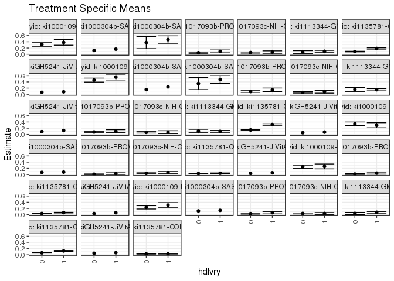

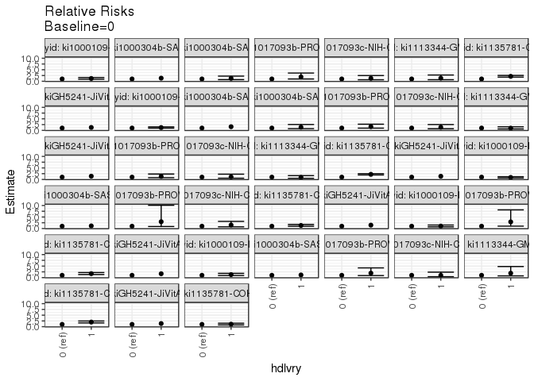

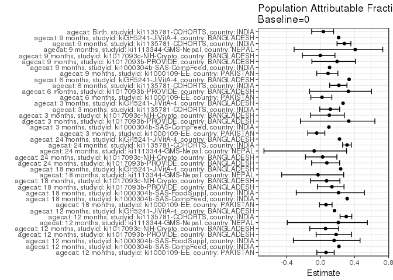

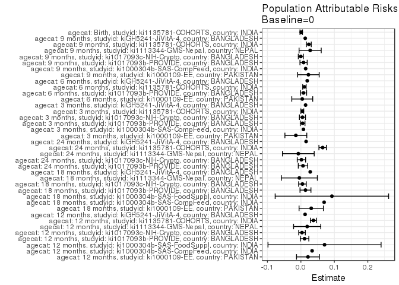

## Results Table

### Parameter: TSM

| agecat | studyid | country | intervention_level | baseline_level | estimate | ci_lower | ci_upper |
| --- | --- | --- | --- | --- | --- | --- | --- |
| Birth | ki1135781-COHORTS | INDIA | 0 | NA | 0.0282505 | 0.0222587 | 0.0342423 |
| Birth | ki1135781-COHORTS | INDIA | 1 | NA | 0.0307517 | 0.0226759 | 0.0388275 |
| 3 months | ki1000109-EE | PAKISTAN | 0 | NA | 0.3412698 | 0.2826517 | 0.3998880 |
| 3 months | ki1000109-EE | PAKISTAN | 1 | NA | 0.2950820 | 0.2140437 | 0.3761202 |
| 3 months | ki1000304b-SAS-CompFeed | INDIA | 0 | NA | 0.0704225 | NA | NA |
| 3 months | ki1000304b-SAS-CompFeed | INDIA | 1 | NA | 0.0798611 | NA | NA |
| 3 months | ki1017093b-PROVIDE | BANGLADESH | 0 | NA | 0.0103734 | 0.0013212 | 0.0194257 |
| 3 months | ki1017093b-PROVIDE | BANGLADESH | 1 | NA | 0.0306748 | 0.0041827 | 0.0571670 |
| 3 months | ki1017093c-NIH-Crypto | BANGLADESH | 0 | NA | 0.0407080 | 0.0244023 | 0.0570136 |
| 3 months | ki1017093c-NIH-Crypto | BANGLADESH | 1 | NA | 0.0613497 | 0.0244850 | 0.0982144 |
| 3 months | ki1135781-COHORTS | INDIA | 0 | NA | 0.0325285 | 0.0261607 | 0.0388963 |
| 3 months | ki1135781-COHORTS | INDIA | 1 | NA | 0.0434084 | 0.0341617 | 0.0526551 |
| 3 months | kiGH5241-JiVitA-4 | BANGLADESH | 0 | NA | 0.0390244 | NA | NA |
| 3 months | kiGH5241-JiVitA-4 | BANGLADESH | 1 | NA | 0.0574534 | NA | NA |
| 6 months | ki1000109-EE | PAKISTAN | 0 | NA | 0.2500000 | 0.1960352 | 0.3039648 |
| 6 months | ki1000109-EE | PAKISTAN | 1 | NA | 0.2622951 | 0.1841337 | 0.3404565 |
| 6 months | ki1017093b-PROVIDE | BANGLADESH | 0 | NA | 0.0161663 | 0.0042773 | 0.0280552 |
| 6 months | ki1017093b-PROVIDE | BANGLADESH | 1 | NA | 0.0466667 | 0.0128834 | 0.0804499 |
| 6 months | ki1135781-COHORTS | INDIA | 0 | NA | 0.0386207 | 0.0316069 | 0.0456345 |
| 6 months | ki1135781-COHORTS | INDIA | 1 | NA | 0.0661479 | 0.0546617 | 0.0776340 |
| 6 months | kiGH5241-JiVitA-4 | BANGLADESH | 0 | NA | 0.0374532 | NA | NA |
| 6 months | kiGH5241-JiVitA-4 | BANGLADESH | 1 | NA | 0.0628205 | NA | NA |
| 9 months | ki1000109-EE | PAKISTAN | 0 | NA | 0.2357724 | 0.1826551 | 0.2888896 |
| 9 months | ki1000109-EE | PAKISTAN | 1 | NA | 0.3050847 | 0.2218929 | 0.3882766 |
| 9 months | ki1000304b-SAS-CompFeed | INDIA | 0 | NA | 0.1212121 | NA | NA |
| 9 months | ki1000304b-SAS-CompFeed | INDIA | 1 | NA | 0.1387900 | NA | NA |
| 9 months | ki1017093b-PROVIDE | BANGLADESH | 0 | NA | 0.0333333 | 0.0167345 | 0.0499322 |
| 9 months | ki1017093b-PROVIDE | BANGLADESH | 1 | NA | 0.0645161 | 0.0258088 | 0.1032235 |
| 9 months | ki1017093c-NIH-Crypto | BANGLADESH | 0 | NA | 0.0398551 | 0.0235247 | 0.0561855 |
| 9 months | ki1017093c-NIH-Crypto | BANGLADESH | 1 | NA | 0.0389610 | 0.0083780 | 0.0695441 |
| 9 months | ki1113344-GMS-Nepal | NEPAL | 0 | NA | 0.0403226 | 0.0056652 | 0.0749800 |
| 9 months | ki1113344-GMS-Nepal | NEPAL | 1 | NA | 0.0767263 | 0.0503193 | 0.1031334 |
| 9 months | ki1135781-COHORTS | INDIA | 0 | NA | 0.0611354 | 0.0517784 | 0.0704923 |
| 9 months | ki1135781-COHORTS | INDIA | 1 | NA | 0.1226955 | 0.1064801 | 0.1389108 |
| 9 months | kiGH5241-JiVitA-4 | BANGLADESH | 0 | NA | 0.0481481 | NA | NA |
| 9 months | kiGH5241-JiVitA-4 | BANGLADESH | 1 | NA | 0.0654912 | NA | NA |
| 12 months | ki1000109-EE | PAKISTAN | 0 | NA | 0.3140496 | 0.2554899 | 0.3726092 |
| 12 months | ki1000109-EE | PAKISTAN | 1 | NA | 0.3805310 | 0.2908859 | 0.4701760 |
| 12 months | ki1000304b-SAS-CompFeed | INDIA | 0 | NA | 0.1216216 | NA | NA |
| 12 months | ki1000304b-SAS-CompFeed | INDIA | 1 | NA | 0.1637631 | NA | NA |
| 12 months | ki1000304b-SAS-FoodSuppl | INDIA | 0 | NA | 0.3750000 | 0.1802528 | 0.5697472 |
| 12 months | ki1000304b-SAS-FoodSuppl | INDIA | 1 | NA | 0.4705882 | 0.3513037 | 0.5898728 |
| 12 months | ki1017093b-PROVIDE | BANGLADESH | 0 | NA | 0.0491071 | 0.0290804 | 0.0691338 |
| 12 months | ki1017093b-PROVIDE | BANGLADESH | 1 | NA | 0.0921053 | 0.0460957 | 0.1381149 |
| 12 months | ki1017093c-NIH-Crypto | BANGLADESH | 0 | NA | 0.0547445 | 0.0356851 | 0.0738040 |
| 12 months | ki1017093c-NIH-Crypto | BANGLADESH | 1 | NA | 0.0696203 | 0.0299079 | 0.1093326 |
| 12 months | ki1113344-GMS-Nepal | NEPAL | 0 | NA | 0.0714286 | 0.0264171 | 0.1164401 |
| 12 months | ki1113344-GMS-Nepal | NEPAL | 1 | NA | 0.0962025 | 0.0670957 | 0.1253094 |
| 12 months | ki1135781-COHORTS | INDIA | 0 | NA | 0.0868607 | 0.0752685 | 0.0984529 |
| 12 months | ki1135781-COHORTS | INDIA | 1 | NA | 0.1859114 | 0.1653606 | 0.2064622 |
| 12 months | kiGH5241-JiVitA-4 | BANGLADESH | 0 | NA | 0.0643939 | NA | NA |
| 12 months | kiGH5241-JiVitA-4 | BANGLADESH | 1 | NA | 0.0810474 | NA | NA |
| 18 months | ki1000109-EE | PAKISTAN | 0 | NA | 0.4576271 | 0.3939737 | 0.5212806 |
| 18 months | ki1000109-EE | PAKISTAN | 1 | NA | 0.5535714 | 0.4613723 | 0.6457706 |
| 18 months | ki1000304b-SAS-CompFeed | INDIA | 0 | NA | 0.1527778 | NA | NA |
| 18 months | ki1000304b-SAS-CompFeed | INDIA | 1 | NA | 0.2407407 | NA | NA |
| 18 months | ki1000304b-SAS-FoodSuppl | INDIA | 0 | NA | 0.3478261 | 0.1520104 | 0.5436418 |
| 18 months | ki1000304b-SAS-FoodSuppl | INDIA | 1 | NA | 0.4754098 | 0.3493351 | 0.6014845 |
| 18 months | ki1017093b-PROVIDE | BANGLADESH | 0 | NA | 0.0895884 | 0.0620200 | 0.1171568 |
| 18 months | ki1017093b-PROVIDE | BANGLADESH | 1 | NA | 0.1438849 | 0.0854855 | 0.2022843 |
| 18 months | ki1017093c-NIH-Crypto | BANGLADESH | 0 | NA | 0.0616016 | 0.0402311 | 0.0829722 |
| 18 months | ki1017093c-NIH-Crypto | BANGLADESH | 1 | NA | 0.0816327 | 0.0373359 | 0.1259295 |
| 18 months | ki1113344-GMS-Nepal | NEPAL | 0 | NA | 0.1550388 | 0.0925191 | 0.2175584 |
| 18 months | ki1113344-GMS-Nepal | NEPAL | 1 | NA | 0.1488251 | 0.1131454 | 0.1845047 |
| 18 months | kiGH5241-JiVitA-4 | BANGLADESH | 0 | NA | 0.0901961 | NA | NA |
| 18 months | kiGH5241-JiVitA-4 | BANGLADESH | 1 | NA | 0.1270648 | NA | NA |
| 24 months | ki1017093b-PROVIDE | BANGLADESH | 0 | NA | 0.0787037 | 0.0532893 | 0.1041181 |
| 24 months | ki1017093b-PROVIDE | BANGLADESH | 1 | NA | 0.1034483 | 0.0538359 | 0.1530607 |
| 24 months | ki1017093c-NIH-Crypto | BANGLADESH | 0 | NA | 0.0664962 | 0.0417767 | 0.0912156 |
| 24 months | ki1017093c-NIH-Crypto | BANGLADESH | 1 | NA | 0.0731707 | 0.0271040 | 0.1192374 |
| 24 months | ki1113344-GMS-Nepal | NEPAL | 0 | NA | 0.1083333 | 0.0526654 | 0.1640013 |
| 24 months | ki1113344-GMS-Nepal | NEPAL | 1 | NA | 0.0979827 | 0.0666693 | 0.1292962 |
| 24 months | ki1135781-COHORTS | INDIA | 0 | NA | 0.1437528 | 0.1291991 | 0.1583065 |
| 24 months | ki1135781-COHORTS | INDIA | 1 | NA | 0.3182504 | 0.2931758 | 0.3433250 |
| 24 months | kiGH5241-JiVitA-4 | BANGLADESH | 0 | NA | 0.0544747 | NA | NA |
| 24 months | kiGH5241-JiVitA-4 | BANGLADESH | 1 | NA | 0.0750000 | NA | NA |

### Parameter: E(Y)

| agecat | studyid | country | intervention_level | baseline_level | estimate | ci_lower | ci_upper |
| --- | --- | --- | --- | --- | --- | --- | --- |
| Birth | ki1135781-COHORTS | INDIA | NA | NA | 0.0291862 | 0.0243703 | 0.0340021 |
| 3 months | ki1000109-EE | PAKISTAN | NA | NA | 0.3262032 | 0.2786256 | 0.3737808 |
| 3 months | ki1000304b-SAS-CompFeed | INDIA | NA | NA | 0.0779944 | NA | NA |
| 3 months | ki1017093b-PROVIDE | BANGLADESH | NA | NA | 0.0155039 | 0.0059620 | 0.0250457 |
| 3 months | ki1017093c-NIH-Crypto | BANGLADESH | NA | NA | 0.0453297 | 0.0302080 | 0.0604513 |
| 3 months | ki1135781-COHORTS | INDIA | NA | NA | 0.0367162 | 0.0314218 | 0.0420106 |
| 3 months | kiGH5241-JiVitA-4 | BANGLADESH | NA | NA | 0.0530035 | NA | NA |
| 6 months | ki1000109-EE | PAKISTAN | NA | NA | 0.2540541 | 0.2096368 | 0.2984713 |
| 6 months | ki1017093b-PROVIDE | BANGLADESH | NA | NA | 0.0240137 | 0.0115761 | 0.0364514 |
| 6 months | ki1135781-COHORTS | INDIA | NA | NA | 0.0491594 | 0.0429771 | 0.0553417 |
| 6 months | kiGH5241-JiVitA-4 | BANGLADESH | NA | NA | 0.0563515 | NA | NA |
| 9 months | ki1000109-EE | PAKISTAN | NA | NA | 0.2582418 | 0.2132183 | 0.3032653 |
| 9 months | ki1000304b-SAS-CompFeed | INDIA | NA | NA | 0.1354467 | NA | NA |
| 9 months | ki1017093b-PROVIDE | BANGLADESH | NA | NA | 0.0413223 | 0.0254493 | 0.0571953 |
| 9 months | ki1017093c-NIH-Crypto | BANGLADESH | NA | NA | 0.0396601 | 0.0252541 | 0.0540660 |
| 9 months | ki1113344-GMS-Nepal | NEPAL | NA | NA | 0.0679612 | 0.0462034 | 0.0897189 |
| 9 months | ki1135781-COHORTS | INDIA | NA | NA | 0.0847996 | 0.0762629 | 0.0933363 |
| 9 months | kiGH5241-JiVitA-4 | BANGLADESH | NA | NA | 0.0610902 | NA | NA |
| 12 months | ki1000109-EE | PAKISTAN | NA | NA | 0.3352113 | 0.2860359 | 0.3843866 |
| 12 months | ki1000304b-SAS-CompFeed | INDIA | NA | NA | 0.1551247 | NA | NA |
| 12 months | ki1000304b-SAS-FoodSuppl | INDIA | NA | NA | 0.4456522 | 0.3435308 | 0.5477735 |
| 12 months | ki1017093b-PROVIDE | BANGLADESH | NA | NA | 0.0600000 | 0.0409816 | 0.0790184 |
| 12 months | ki1017093c-NIH-Crypto | BANGLADESH | NA | NA | 0.0580737 | 0.0408093 | 0.0753381 |
| 12 months | ki1113344-GMS-Nepal | NEPAL | NA | NA | 0.0902111 | 0.0655878 | 0.1148345 |
| 12 months | ki1135781-COHORTS | INDIA | NA | NA | 0.1242798 | 0.1135685 | 0.1349911 |
| 12 months | kiGH5241-JiVitA-4 | BANGLADESH | NA | NA | 0.0769231 | NA | NA |
| 18 months | ki1000109-EE | PAKISTAN | NA | NA | 0.4885057 | 0.4359115 | 0.5411000 |
| 18 months | ki1000304b-SAS-CompFeed | INDIA | NA | NA | 0.2222222 | NA | NA |
| 18 months | ki1000304b-SAS-FoodSuppl | INDIA | NA | NA | 0.4404762 | 0.3336742 | 0.5472782 |
| 18 months | ki1017093b-PROVIDE | BANGLADESH | NA | NA | 0.1032609 | 0.0778527 | 0.1286690 |
| 18 months | ki1017093c-NIH-Crypto | BANGLADESH | NA | NA | 0.0662461 | 0.0468710 | 0.0856211 |
| 18 months | ki1113344-GMS-Nepal | NEPAL | NA | NA | 0.1503906 | 0.1193980 | 0.1813832 |
| 18 months | kiGH5241-JiVitA-4 | BANGLADESH | NA | NA | 0.1180422 | NA | NA |
| 24 months | ki1017093b-PROVIDE | BANGLADESH | NA | NA | 0.0849220 | 0.0621566 | 0.1076874 |
| 24 months | ki1017093c-NIH-Crypto | BANGLADESH | NA | NA | 0.0680934 | 0.0462948 | 0.0898920 |
| 24 months | ki1113344-GMS-Nepal | NEPAL | NA | NA | 0.1006424 | 0.0733267 | 0.1279581 |
| 24 months | ki1135781-COHORTS | INDIA | NA | NA | 0.2087665 | 0.1954120 | 0.2221210 |
| 24 months | kiGH5241-JiVitA-4 | BANGLADESH | NA | NA | 0.0700095 | NA | NA |

### Parameter: RR

| agecat | studyid | country | intervention_level | baseline_level | estimate | ci_lower | ci_upper |
| --- | --- | --- | --- | --- | --- | --- | --- |
| Birth | ki1135781-COHORTS | INDIA | 0 | 0 | 1.0000000 | 1.0000000 | 1.000000 |
| Birth | ki1135781-COHORTS | INDIA | 1 | 0 | 1.0885364 | 0.7766770 | 1.525617 |
| 3 months | ki1000109-EE | PAKISTAN | 0 | 0 | 1.0000000 | 1.0000000 | 1.000000 |
| 3 months | ki1000109-EE | PAKISTAN | 1 | 0 | 0.8646588 | 0.6254143 | 1.195423 |
| 3 months | ki1000304b-SAS-CompFeed | INDIA | 0 | 0 | 1.0000000 | NA | NA |
| 3 months | ki1000304b-SAS-CompFeed | INDIA | 1 | 0 | 1.1340278 | NA | NA |
| 3 months | ki1017093b-PROVIDE | BANGLADESH | 0 | 0 | 1.0000000 | 1.0000000 | 1.000000 |
| 3 months | ki1017093b-PROVIDE | BANGLADESH | 1 | 0 | 2.9570552 | 0.8662675 | 10.094083 |
| 3 months | ki1017093c-NIH-Crypto | BANGLADESH | 0 | 0 | 1.0000000 | 1.0000000 | 1.000000 |
| 3 months | ki1017093c-NIH-Crypto | BANGLADESH | 1 | 0 | 1.5070686 | 0.7319858 | 3.102869 |
| 3 months | ki1135781-COHORTS | INDIA | 0 | 0 | 1.0000000 | 1.0000000 | 1.000000 |
| 3 months | ki1135781-COHORTS | INDIA | 1 | 0 | 1.3344714 | 0.9992287 | 1.782189 |
| 3 months | kiGH5241-JiVitA-4 | BANGLADESH | 0 | 0 | 1.0000000 | NA | NA |
| 3 months | kiGH5241-JiVitA-4 | BANGLADESH | 1 | 0 | 1.4722438 | NA | NA |
| 6 months | ki1000109-EE | PAKISTAN | 0 | 0 | 1.0000000 | 1.0000000 | 1.000000 |
| 6 months | ki1000109-EE | PAKISTAN | 1 | 0 | 1.0491803 | 0.7261859 | 1.515837 |
| 6 months | ki1017093b-PROVIDE | BANGLADESH | 0 | 0 | 1.0000000 | 1.0000000 | 1.000000 |
| 6 months | ki1017093b-PROVIDE | BANGLADESH | 1 | 0 | 2.8866667 | 1.0285604 | 8.101463 |
| 6 months | ki1135781-COHORTS | INDIA | 0 | 0 | 1.0000000 | 1.0000000 | 1.000000 |
| 6 months | ki1135781-COHORTS | INDIA | 1 | 0 | 1.7127571 | 1.3322122 | 2.202004 |
| 6 months | kiGH5241-JiVitA-4 | BANGLADESH | 0 | 0 | 1.0000000 | NA | NA |
| 6 months | kiGH5241-JiVitA-4 | BANGLADESH | 1 | 0 | 1.6773077 | NA | NA |
| 9 months | ki1000109-EE | PAKISTAN | 0 | 0 | 1.0000000 | 1.0000000 | 1.000000 |
| 9 months | ki1000109-EE | PAKISTAN | 1 | 0 | 1.2939801 | 0.9084734 | 1.843075 |
| 9 months | ki1000304b-SAS-CompFeed | INDIA | 0 | 0 | 1.0000000 | NA | NA |
| 9 months | ki1000304b-SAS-CompFeed | INDIA | 1 | 0 | 1.1450178 | NA | NA |
| 9 months | ki1017093b-PROVIDE | BANGLADESH | 0 | 0 | 1.0000000 | 1.0000000 | 1.000000 |
| 9 months | ki1017093b-PROVIDE | BANGLADESH | 1 | 0 | 1.9354839 | 0.8875061 | 4.220926 |
| 9 months | ki1017093c-NIH-Crypto | BANGLADESH | 0 | 0 | 1.0000000 | 1.0000000 | 1.000000 |
| 9 months | ki1017093c-NIH-Crypto | BANGLADESH | 1 | 0 | 0.9775679 | 0.4032655 | 2.369752 |
| 9 months | ki1113344-GMS-Nepal | NEPAL | 0 | 0 | 1.0000000 | 1.0000000 | 1.000000 |
| 9 months | ki1113344-GMS-Nepal | NEPAL | 1 | 0 | 1.9028131 | 0.7538832 | 4.802730 |
| 9 months | ki1135781-COHORTS | INDIA | 0 | 0 | 1.0000000 | 1.0000000 | 1.000000 |
| 9 months | ki1135781-COHORTS | INDIA | 1 | 0 | 2.0069476 | 1.6395124 | 2.456730 |
| 9 months | kiGH5241-JiVitA-4 | BANGLADESH | 0 | 0 | 1.0000000 | NA | NA |
| 9 months | kiGH5241-JiVitA-4 | BANGLADESH | 1 | 0 | 1.3602015 | NA | NA |
| 12 months | ki1000109-EE | PAKISTAN | 0 | 0 | 1.0000000 | 1.0000000 | 1.000000 |
| 12 months | ki1000109-EE | PAKISTAN | 1 | 0 | 1.2116907 | 0.8972435 | 1.636339 |
| 12 months | ki1000304b-SAS-CompFeed | INDIA | 0 | 0 | 1.0000000 | NA | NA |
| 12 months | ki1000304b-SAS-CompFeed | INDIA | 1 | 0 | 1.3464963 | NA | NA |
| 12 months | ki1000304b-SAS-FoodSuppl | INDIA | 0 | 0 | 1.0000000 | 1.0000000 | 1.000000 |
| 12 months | ki1000304b-SAS-FoodSuppl | INDIA | 1 | 0 | 1.2549020 | 0.7041050 | 2.236569 |
| 12 months | ki1017093b-PROVIDE | BANGLADESH | 0 | 0 | 1.0000000 | 1.0000000 | 1.000000 |
| 12 months | ki1017093b-PROVIDE | BANGLADESH | 1 | 0 | 1.8755981 | 0.9841916 | 3.574373 |
| 12 months | ki1017093c-NIH-Crypto | BANGLADESH | 0 | 0 | 1.0000000 | 1.0000000 | 1.000000 |
| 12 months | ki1017093c-NIH-Crypto | BANGLADESH | 1 | 0 | 1.2717300 | 0.6518834 | 2.480961 |
| 12 months | ki1113344-GMS-Nepal | NEPAL | 0 | 0 | 1.0000000 | 1.0000000 | 1.000000 |
| 12 months | ki1113344-GMS-Nepal | NEPAL | 1 | 0 | 1.3468354 | 0.6694669 | 2.709567 |
| 12 months | ki1135781-COHORTS | INDIA | 0 | 0 | 1.0000000 | 1.0000000 | 1.000000 |
| 12 months | ki1135781-COHORTS | INDIA | 1 | 0 | 2.1403404 | 1.7997946 | 2.545322 |
| 12 months | kiGH5241-JiVitA-4 | BANGLADESH | 0 | 0 | 1.0000000 | NA | NA |
| 12 months | kiGH5241-JiVitA-4 | BANGLADESH | 1 | 0 | 1.2586182 | NA | NA |
| 18 months | ki1000109-EE | PAKISTAN | 0 | 0 | 1.0000000 | 1.0000000 | 1.000000 |
| 18 months | ki1000109-EE | PAKISTAN | 1 | 0 | 1.2096561 | 0.9736923 | 1.502803 |
| 18 months | ki1000304b-SAS-CompFeed | INDIA | 0 | 0 | 1.0000000 | NA | NA |
| 18 months | ki1000304b-SAS-CompFeed | INDIA | 1 | 0 | 1.5757576 | NA | NA |
| 18 months | ki1000304b-SAS-FoodSuppl | INDIA | 0 | 0 | 1.0000000 | 1.0000000 | 1.000000 |
| 18 months | ki1000304b-SAS-FoodSuppl | INDIA | 1 | 0 | 1.3668033 | 0.7335723 | 2.546649 |
| 18 months | ki1017093b-PROVIDE | BANGLADESH | 0 | 0 | 1.0000000 | 1.0000000 | 1.000000 |
| 18 months | ki1017093b-PROVIDE | BANGLADESH | 1 | 0 | 1.6060665 | 0.9650715 | 2.672807 |
| 18 months | ki1017093c-NIH-Crypto | BANGLADESH | 0 | 0 | 1.0000000 | 1.0000000 | 1.000000 |
| 18 months | ki1017093c-NIH-Crypto | BANGLADESH | 1 | 0 | 1.3251701 | 0.6959259 | 2.523366 |
| 18 months | ki1113344-GMS-Nepal | NEPAL | 0 | 0 | 1.0000000 | 1.0000000 | 1.000000 |
| 18 months | ki1113344-GMS-Nepal | NEPAL | 1 | 0 | 0.9599217 | 0.6004721 | 1.534542 |
| 18 months | kiGH5241-JiVitA-4 | BANGLADESH | 0 | 0 | 1.0000000 | NA | NA |
| 18 months | kiGH5241-JiVitA-4 | BANGLADESH | 1 | 0 | 1.4087618 | NA | NA |
| 24 months | ki1017093b-PROVIDE | BANGLADESH | 0 | 0 | 1.0000000 | 1.0000000 | 1.000000 |
| 24 months | ki1017093b-PROVIDE | BANGLADESH | 1 | 0 | 1.3144016 | 0.7372825 | 2.343270 |
| 24 months | ki1017093c-NIH-Crypto | BANGLADESH | 0 | 0 | 1.0000000 | 1.0000000 | 1.000000 |
| 24 months | ki1017093c-NIH-Crypto | BANGLADESH | 1 | 0 | 1.1003752 | 0.5296782 | 2.285965 |
| 24 months | ki1113344-GMS-Nepal | NEPAL | 0 | 0 | 1.0000000 | 1.0000000 | 1.000000 |
| 24 months | ki1113344-GMS-Nepal | NEPAL | 1 | 0 | 0.9044558 | 0.4938359 | 1.656502 |
| 24 months | ki1135781-COHORTS | INDIA | 0 | 0 | 1.0000000 | 1.0000000 | 1.000000 |
| 24 months | ki1135781-COHORTS | INDIA | 1 | 0 | 2.2138726 | 1.9473253 | 2.516904 |
| 24 months | kiGH5241-JiVitA-4 | BANGLADESH | 0 | 0 | 1.0000000 | NA | NA |
| 24 months | kiGH5241-JiVitA-4 | BANGLADESH | 1 | 0 | 1.3767857 | NA | NA |

### Parameter: PAR

| agecat | studyid | country | intervention_level | baseline_level | estimate | ci_lower | ci_upper |
| --- | --- | --- | --- | --- | --- | --- | --- |
| Birth | ki1135781-COHORTS | INDIA | 0 | NA | 0.0009357 | -0.0028263 | 0.0046977 |
| 3 months | ki1000109-EE | PAKISTAN | 0 | NA | -0.0150666 | -0.0477662 | 0.0176330 |
| 3 months | ki1000304b-SAS-CompFeed | INDIA | 0 | NA | 0.0075719 | NA | NA |
| 3 months | ki1017093b-PROVIDE | BANGLADESH | 0 | NA | 0.0051304 | -0.0019773 | 0.0122381 |
| 3 months | ki1017093c-NIH-Crypto | BANGLADESH | 0 | NA | 0.0046217 | -0.0044254 | 0.0136688 |
| 3 months | ki1135781-COHORTS | INDIA | 0 | NA | 0.0041877 | -0.0001363 | 0.0085116 |
| 3 months | kiGH5241-JiVitA-4 | BANGLADESH | 0 | NA | 0.0139791 | NA | NA |
| 6 months | ki1000109-EE | PAKISTAN | 0 | NA | 0.0040541 | -0.0272696 | 0.0353777 |
| 6 months | ki1017093b-PROVIDE | BANGLADESH | 0 | NA | 0.0078474 | -0.0014306 | 0.0171255 |
| 6 months | ki1135781-COHORTS | INDIA | 0 | NA | 0.0105387 | 0.0053720 | 0.0157054 |
| 6 months | kiGH5241-JiVitA-4 | BANGLADESH | 0 | NA | 0.0188983 | NA | NA |
| 9 months | ki1000109-EE | PAKISTAN | 0 | NA | 0.0224694 | -0.0097014 | 0.0546402 |
| 9 months | ki1000304b-SAS-CompFeed | INDIA | 0 | NA | 0.0142346 | NA | NA |
| 9 months | ki1017093b-PROVIDE | BANGLADESH | 0 | NA | 0.0079890 | -0.0028556 | 0.0188336 |
| 9 months | ki1017093c-NIH-Crypto | BANGLADESH | 0 | NA | -0.0001950 | -0.0077576 | 0.0073676 |
| 9 months | ki1113344-GMS-Nepal | NEPAL | 0 | NA | 0.0276386 | -0.0054692 | 0.0607464 |
| 9 months | ki1135781-COHORTS | INDIA | 0 | NA | 0.0236642 | 0.0164093 | 0.0309192 |
| 9 months | kiGH5241-JiVitA-4 | BANGLADESH | 0 | NA | 0.0129421 | NA | NA |
| 12 months | ki1000109-EE | PAKISTAN | 0 | NA | 0.0211617 | -0.0130743 | 0.0553976 |
| 12 months | ki1000304b-SAS-CompFeed | INDIA | 0 | NA | 0.0335030 | NA | NA |
| 12 months | ki1000304b-SAS-FoodSuppl | INDIA | 0 | NA | 0.0706522 | -0.0983671 | 0.2396715 |
| 12 months | ki1017093b-PROVIDE | BANGLADESH | 0 | NA | 0.0108929 | -0.0019071 | 0.0236928 |
| 12 months | ki1017093c-NIH-Crypto | BANGLADESH | 0 | NA | 0.0033291 | -0.0065395 | 0.0131978 |
| 12 months | ki1113344-GMS-Nepal | NEPAL | 0 | NA | 0.0187826 | -0.0218669 | 0.0594321 |
| 12 months | ki1135781-COHORTS | INDIA | 0 | NA | 0.0374192 | 0.0283702 | 0.0464681 |
| 12 months | kiGH5241-JiVitA-4 | BANGLADESH | 0 | NA | 0.0125291 | NA | NA |
| 18 months | ki1000109-EE | PAKISTAN | 0 | NA | 0.0308786 | -0.0054866 | 0.0672438 |
| 18 months | ki1000304b-SAS-CompFeed | INDIA | 0 | NA | 0.0694444 | NA | NA |
| 18 months | ki1000304b-SAS-FoodSuppl | INDIA | 0 | NA | 0.0926501 | -0.0769160 | 0.2622163 |
| 18 months | ki1017093b-PROVIDE | BANGLADESH | 0 | NA | 0.0136725 | -0.0027080 | 0.0300530 |
| 18 months | ki1017093c-NIH-Crypto | BANGLADESH | 0 | NA | 0.0046444 | -0.0067781 | 0.0160669 |
| 18 months | ki1113344-GMS-Nepal | NEPAL | 0 | NA | -0.0046481 | -0.0584963 | 0.0492000 |
| 18 months | kiGH5241-JiVitA-4 | BANGLADESH | 0 | NA | 0.0278461 | NA | NA |
| 24 months | ki1017093b-PROVIDE | BANGLADESH | 0 | NA | 0.0062183 | -0.0078173 | 0.0202539 |
| 24 months | ki1017093c-NIH-Crypto | BANGLADESH | 0 | NA | 0.0015972 | -0.0109158 | 0.0141102 |
| 24 months | ki1113344-GMS-Nepal | NEPAL | 0 | NA | -0.0076909 | -0.0551512 | 0.0397693 |
| 24 months | ki1135781-COHORTS | INDIA | 0 | NA | 0.0650137 | 0.0538619 | 0.0761656 |
| 24 months | kiGH5241-JiVitA-4 | BANGLADESH | 0 | NA | 0.0155348 | NA | NA |

### Parameter: PAF

| agecat | studyid | country | intervention_level | baseline_level | estimate | ci_lower | ci_upper |
| --- | --- | --- | --- | --- | --- | --- | --- |
| Birth | ki1135781-COHORTS | INDIA | 0 | NA | 0.0320591 | -0.1056968 | 0.1526524 |
| 3 months | ki1000109-EE | PAKISTAN | 0 | NA | -0.0461879 | -0.1513938 | 0.0494051 |
| 3 months | ki1000304b-SAS-CompFeed | INDIA | 0 | NA | 0.0970825 | NA | NA |
| 3 months | ki1017093b-PROVIDE | BANGLADESH | 0 | NA | 0.3309129 | -0.2381371 | 0.6384265 |
| 3 months | ki1017093c-NIH-Crypto | BANGLADESH | 0 | NA | 0.1019576 | -0.1182144 | 0.2787786 |
| 3 months | ki1135781-COHORTS | INDIA | 0 | NA | 0.1140551 | -0.0106694 | 0.2233877 |
| 3 months | kiGH5241-JiVitA-4 | BANGLADESH | 0 | NA | 0.2637398 | NA | NA |
| 6 months | ki1000109-EE | PAKISTAN | 0 | NA | 0.0159574 | -0.1153830 | 0.1318320 |
| 6 months | ki1017093b-PROVIDE | BANGLADESH | 0 | NA | 0.3267898 | -0.1300269 | 0.5989370 |
| 6 months | ki1135781-COHORTS | INDIA | 0 | NA | 0.2143783 | 0.1056046 | 0.3099232 |
| 6 months | kiGH5241-JiVitA-4 | BANGLADESH | 0 | NA | 0.3353647 | NA | NA |
| 9 months | ki1000109-EE | PAKISTAN | 0 | NA | 0.0870092 | -0.0460802 | 0.2031660 |
| 9 months | ki1000304b-SAS-CompFeed | INDIA | 0 | NA | 0.1050935 | NA | NA |
| 9 months | ki1017093b-PROVIDE | BANGLADESH | 0 | NA | 0.1933333 | -0.1031157 | 0.4101153 |
| 9 months | ki1017093c-NIH-Crypto | BANGLADESH | 0 | NA | -0.0049172 | -0.2148863 | 0.1687629 |
| 9 months | ki1113344-GMS-Nepal | NEPAL | 0 | NA | 0.4066820 | -0.3123363 | 0.7317560 |
| 9 months | ki1135781-COHORTS | INDIA | 0 | NA | 0.2790607 | 0.1928205 | 0.3560869 |
| 9 months | kiGH5241-JiVitA-4 | BANGLADESH | 0 | NA | 0.2118518 | NA | NA |
| 12 months | ki1000109-EE | PAKISTAN | 0 | NA | 0.0631294 | -0.0447522 | 0.1598710 |
| 12 months | ki1000304b-SAS-CompFeed | INDIA | 0 | NA | 0.2159749 | NA | NA |
| 12 months | ki1000304b-SAS-FoodSuppl | INDIA | 0 | NA | 0.1585366 | -0.3215888 | 0.4642352 |
| 12 months | ki1017093b-PROVIDE | BANGLADESH | 0 | NA | 0.1815476 | -0.0530374 | 0.3638742 |
| 12 months | ki1017093c-NIH-Crypto | BANGLADESH | 0 | NA | 0.0573260 | -0.1279815 | 0.2121907 |
| 12 months | ki1113344-GMS-Nepal | NEPAL | 0 | NA | 0.2082067 | -0.3934876 | 0.5500953 |
| 12 months | ki1135781-COHORTS | INDIA | 0 | NA | 0.3010880 | 0.2285619 | 0.3667956 |
| 12 months | kiGH5241-JiVitA-4 | BANGLADESH | 0 | NA | 0.1628788 | NA | NA |
| 18 months | ki1000109-EE | PAKISTAN | 0 | NA | 0.0632104 | -0.0145345 | 0.1349976 |
| 18 months | ki1000304b-SAS-CompFeed | INDIA | 0 | NA | 0.3125000 | NA | NA |
| 18 months | ki1000304b-SAS-FoodSuppl | INDIA | 0 | NA | 0.2103408 | -0.2870962 | 0.5155283 |
| 18 months | ki1017093b-PROVIDE | BANGLADESH | 0 | NA | 0.1324073 | -0.0384160 | 0.2751295 |
| 18 months | ki1017093c-NIH-Crypto | BANGLADESH | 0 | NA | 0.0701085 | -0.1180611 | 0.2266092 |
| 18 months | ki1113344-GMS-Nepal | NEPAL | 0 | NA | -0.0309071 | -0.4589612 | 0.2715575 |
| 18 months | kiGH5241-JiVitA-4 | BANGLADESH | 0 | NA | 0.2358998 | NA | NA |
| 24 months | ki1017093b-PROVIDE | BANGLADESH | 0 | NA | 0.0732237 | -0.1065501 | 0.2237909 |
| 24 months | ki1017093c-NIH-Crypto | BANGLADESH | 0 | NA | 0.0234563 | -0.1785745 | 0.1908551 |
| 24 months | ki1113344-GMS-Nepal | NEPAL | 0 | NA | -0.0764184 | -0.6676441 | 0.3052015 |
| 24 months | ki1135781-COHORTS | INDIA | 0 | NA | 0.3114183 | 0.2584840 | 0.3605738 |
| 24 months | kiGH5241-JiVitA-4 | BANGLADESH | 0 | NA | 0.2218950 | NA | NA |